# Text as Data - Homework 1

*Thomas Herold, NYU Department of Sociology*

### Computing environment

We will use the following R packages.

```
library(quanteda)
library(quantedaData)
library(stringr)
library(ggbiplot)
library(dplyr)
```

To ensure consistent runs, we set the seed before performing any analysis.

```
set.seed(2016)
```

## Question 1

First we get the data, and find the two Obama speeches of interest (2009, 2016).

```
data("SOTUCorpus")
str(SOTUCorpus)
```

[output not shown]

```
speeches<-data.frame(SOTUCorpus$documents)
names(speeches)
```

```
[1] "texts"     "FirstName" "President" "Date"      "delivery"  "type"      "filename"  "party"
```

```
length(speeches$texts)
```

```
[1] 230
```

```
ob16 <- speeches$texts[speeches$President == "Obama" &  substr(speeches$Date,1,4) == "2016" ]
ob09 <- speeches$texts[speeches$President == "Obama" &  substr(speeches$Date,1,4) == "2009" ]
```

Here is a function that calculates the ttr. Note that I decided to keep `removePunct = TRUE` for the tokenizer. If not, punctuation symbols would be counted as tokens, which does not make much sense for calculating the TTR.

```
ttr <- function(data,
                # parameters we want to mess with
                stem = FALSE, removeStopwords = FALSE, toLower = FALSE,
                # I decided to set this to true
                removePunct = TRUE) {
  if (toLower == TRUE) (data <- toLower(data))
  tokens <- tokenize(data, removePunct = removePunct)
  if (removeStopwords == TRUE) (tokens <- removeFeatures(tokens, stopwords("english")))
  if (stem == TRUE) (tokens <- wordstem(tokens))
  tokenz <- lengths(tokens)
  typez <- ntype(tokens)
  ttr <- typez / tokenz
  return(ttr)
}
```

Since all function parameters are set to FALSE, I can just use my ttr function w/o further specification to get a TTR after **only** removing punctuation! I’ll try out different pre-processing option. We expect the following:

- `stem`: TTR should be lower, since the number of token remains the same and the number of types decreases
- `removeStopwords`: This should give us much higher TTRs since when excluding words like *and* or *or*, we only exclude one type each but *many* tokens.
- `toLower`: We expect the TTR to get smaller for the same reason as with `stem`.

```
ttr(ob09)
```

```
[1] 0.2598451
```

```
ttr(ob16)
```

```
[1] 0.2789161
```

```
# cet. par., this should give us lower TTR's
ttr(ob09, stem = TRUE)
```

```
[1] 0.2201351
```

```
ttr(ob16, stem = TRUE)
```

```
[1] 0.2392597
```

```
# cet. par., this should give us (much) higher TTR's
ttr(ob09, removeStopwords = TRUE)
```

```
[1] 0.4444085
```

```
ttr(ob16, removeStopwords = TRUE)
```

```
[1] 0.4723569
```

```
# cet. par., this should give lower TTR's:
ttr(ob09, toLower = TRUE)
```

```
[1] 0.2484759
```

```
ttr(ob16, toLower = TRUE)
```

```
[1] 0.2635492
```

The following functions takes care of calculating the cosine similarity under the different scenarios. It takes in the two documents (note: no function parameter for the data), converts them to a dfm with the specified pre-processing steps, and then calculates the resulting cosine similarity.

```
obCosSim <- function(# no function parameter for data!
                     # parameters we want to mess with:
                     stem = FALSE, removeStopwords = FALSE, toLower = FALSE,
                     # other settings (again, I will remove punctuation!):
                     removePunct = TRUE,
                     removeNumbers = FALSE) {
  ignoredFeatures <- NULL
  if(removeStopwords == TRUE) (ignoredFeatures <- stopwords("english"))
  obama_dfm <- dfm(c(ob09, ob16),
                 # parameters that we are about to mess with
                 stem = stem, toLower = toLower, ignoredFeatures = ignoredFeatures,
                 # other settings
                 removeNumbers = removeNumbers,
                 removePunct = removePunct,
                 # set this to FALSE to keep function output clean
                 verbose = FALSE)
  cosSim <- as.matrix(similarity(obama_dfm, margin = "documents"))[1,2]
  cat("Settings: stem = ", stem, ", removeStopwords = ", removeStopwords,
      ", toLower = ", toLower, ", removePunct = ", removePunct,
      ", removeNumbers = ", removeNumbers,
      "\nCosine Similarity: cos.sim(ob09, ob16) = ", round(cosSim,4), sep = "")
}
```

Now let’s apply the function under the different scenarios:

```
# cosine similarity with no other pre-processing than removePunct = TRUE
obCosSim()
```

```
Settings: stem = FALSE, removeStopwords = FALSE, toLower = FALSE, removePunct = TRUE, removeNumbers = FALSE
Cosine Similarity: cos.sim(ob09, ob16) = 0.956
```

```
# after stemming
obCosSim(stem = TRUE)
```

```
Settings: stem = TRUE, removeStopwords = FALSE, toLower = FALSE, removePunct = TRUE, removeNumbers = FALSE
Cosine Similarity: cos.sim(ob09, ob16) = 0.9548
```

```
# after removing stopwords
obCosSim(removeStopwords = TRUE)
```

```
Settings: stem = FALSE, removeStopwords = TRUE, toLower = FALSE, removePunct = TRUE, removeNumbers = FALSE
Cosine Similarity: cos.sim(ob09, ob16) = 0.6763
```

```
# after converting to lowercase
obCosSim(toLower=TRUE)
```

```
Settings: stem = FALSE, removeStopwords = FALSE, toLower = TRUE, removePunct = TRUE, removeNumbers = FALSE
Cosine Similarity: cos.sim(ob09, ob16) = 0.9626
```

Now let’s look at the MTLD.

**Idea:** Write a function that finds 25 starting points (no overlaps!) -> non-random initialization: lengths(tokens) of speech, subtract an appropriate number of words, then distribute starting uniformly.

We are going to set: `stem = FALSE`, `removeStopwords = FALSE`, `toLower = FALSE`, `removePunct = TRUE`

```
mtld <- function(data, inits = 25) {
  res <- list()
  tokens <- tokenize(data, removePunct = TRUE)
  tokenz <- lengths(tokens)
  typez <- ntype(tokens)
  res$ttr <- c("overall TTR", round(typez / tokenz,4))
  positions <- round(seq(50, tokenz - 100, length.out = inits))
  res$mat <- matrix(0, nrow=inits, ncol=4,
                    dimnames = list(NULL ,c("start", "end", "nwords", "flag")))
  for (i in 1:length(positions)) {
    start <- positions[i]
    if (i>1) (if (start <= res$mat[i-1, 2]) (res$mat[i,4] <- 1))
    j <- 2; ttr = 1
    while (ttr >= .72) {
      typ <- length(unique(tokens[[1]][start:(start+j)]))
      tok <- length(tokens[[1]][start:(start+j)])
      ttr <- typ / tok
      res$mat[i,1:3] <- c(positions[i], positions[i]+j, j)
      j <- j + 1
    }
  }
  if (sum(res$mat[,4])>0) (warning("Overlapping search regions.\nCheck flag vector returned by this function ($mat[,4])."))
  res$mtld <- mean(res$mat[,3])
  cat("MTLD = ", res$mtld, "\n[Check output object for more detailed results]", sep="")
  return(res)
}
```

Now let’s apply the function:

```
mtld.09 <- mtld(ob09)
```

```
MTLD = 99.88
[Check output object for more detailed results]
```

```
mtld.16 <- mtld(ob16)
```

```
MTLD = 114.68
[Check output object for more detailed results]
```

Note that the function prints the main result to the screen. But let’s also inspect the object the function returns:

```
# we could check the matrix
mtld.16$mat
```

```
      start  end nwords flag
 [1,]    50  205    155    0
 [2,]   296  323     27    0
 [3,]   542  612     70    0
 [4,]   788  942    154    0
 [5,]  1034 1143    109    0
 [6,]  1280 1381    101    0
 [7,]  1526 1674    148    0
 [8,]  1771 1998    227    0
 [9,]  2017 2165    148    0
[10,]  2263 2383    120    0
[11,]  2509 2667    158    0
[12,]  2755 2821     66    0
[13,]  3001 3195    194    0
[14,]  3247 3366    119    0
[15,]  3493 3638    145    0
[16,]  3739 3891    152    0
[17,]  3985 4122    137    0
[18,]  4231 4336    105    0
[19,]  4476 4582    106    0
[20,]  4722 4787     65    0
[21,]  4968 5016     48    0
[22,]  5214 5352    138    0
[23,]  5460 5462      2    0
[24,]  5706 5785     79    0
[25,]  5952 6046     94    0
```

```
# the overall TTR
mtld.16$ttr
```

```
[1] "overall TTR" "0.2789"
```

```
# or print the MTLD again
mtld.16$mtld
```

```
[1] 114.68
```

Why did I program in a warning and a flag vector? Let’s imagine someone chooses too many starting points:

```
mtld.09.bad <- mtld(ob09, inits = 40)
```

```
Warning in mtld(ob09, inits = 40): Overlapping search regions.
Check flag vector returned by this function ($mat[,4]).
```

```
MTLD = 105.025
[Check output object for more detailed results]
```

```
# we are being thrown a warning and can inspect the flag vector in $mat:
mtld.09.bad$mat
```

```
      start  end nwords flag
 [1,]    50  179    129    0
 [2,]   202  267     65    0
 [3,]   354  513    159    0
 [4,]   505  645    140    1
 [5,]   657  791    134    0
 [6,]   809  954    145    0
 [7,]   961  970      9    0
 [8,]  1112 1282    170    0
 [9,]  1264 1344     80    1
[10,]  1416 1495     79    0
[11,]  1568 1709    141    0
[12,]  1719 1823    104    0
[13,]  1871 1929     58    0
[14,]  2023 2043     20    0
```

[output cut: 26 more lines]

-> The function detected the overlapping search regions!

## Question 2

Again, we read in the data.

```
v1 <- "The tip of the tongue taking a trip of three steps down the palate to tap, at three, on the teeth."
v2 <- "Kevin tripped and chipped his tooth on the way to platform number three."
```

Let’s first build the vocabulary. I get rid of punctuation using stringr & make everything lowercase. Then, we manually create the tdm.

```
v1_c <- tolower(str_replace_all(v1, "[[:punct:]]", ""))
v2_c <- tolower(str_replace_all(v2, "[[:punct:]]", ""))
# to achieve the same in base R, we could say:
# tolower(gsub(pattern="[[:punct:]]", v1, replacement=""))

dupl <- unlist(strsplit(c(v1_c, v2_c), split = " "))
vocab <- unique(dupl)

string1 <- strsplit(v1_c, split = " ")[[1]]
string2 <- strsplit(v2_c, split = " ")[[1]]

tdm <- matrix(0, nrow = length(vocab), ncol = 2,dimnames = list(vocab,c("v1","v2")))
for (i in 1:length(vocab)) {
  for (j in 1:length(string1)) {
    res <- string1[j] == vocab[i]
    tdm[i,1] <- tdm[i,1] + res
  }
  for (k in 1:length(string2)) {
    res <- string2[k] == vocab[i]
    tdm[i,2] <- tdm[i,2] + res
  }
}
```

Now we have managed to represent each document as a 25-dimensional vector. Let’s define the necessary functions next.

```
len <- function(x) {
  return(sqrt(sum(x^2)))
}
cosSim <- function(x,y) {
  return(t(x) %*% y / (len(x)*len(y)))
}
angle <- function(x,y) {
  return(acos(cosSim(x,y))*(180/pi))
}
euclid <- function(x,y) {
  return(len(x-y))
}
manhattan <- function(x,y) {
  return(sum(abs(x-y)))
}
```

Let’s start with cosine similarity.

```
cosSim(tdm[,1], tdm[,2])
```

```
          [,1]
[1,] 0.3647686
```

```
acos(cosSim(tdm[,1], tdm[,2]))*(180/pi)
```

```
         [,1]
[1,] 68.60666
```

```
# just for fun, let's remove stopwords and again
# (should be lower now!)
ind <- rownames(tdm) %in% stopwords()
tdm.stop <- tdm[!ind,]
cosSim(tdm.stop[,1], tdm.stop[,2])
```

```
          [,1]
[1,] 0.2041241
```

```
# get the angle
acos(cosSim(tdm.stop[,1], tdm.stop[,2]))*(180/pi)
```

```
         [,1]
[1,] 78.22177
```

Next, Euclidean distance. It turns out that this is just what our `len()` function does! Remember the example from class?

```
yi <- c(0.00, 0.00, 1.38, 1.52, 0.00)
yj <- c(0.00, 2.13, 3.24, 0.01, 0.06)
len(yi - yj)
```

```
[1] 3.206275
```

```
# vs.
euclid(yi, yj)
```

```
[1] 3.206275
```

So here:

```
# Euclidean Distance
euclid(tdm[,1],tdm[,2])
```

```
[1] 5.830952
```

```
euclid(tdm.stop[,1],tdm.stop[,2])
```

```
[1] 4
```

```
## Manhattan Distance
manhattan(tdm[,1], tdm[,2])
```

```
[1] 26
```

```
manhattan(tdm.stop[,1], tdm.stop[,2])
```

```
[1] 16
```

## Question 3

Set WD and read in files. Put together corpus - note that I already convert all the texts `toLower`. I also cut off the start and end bit that contains meta info by Gutenberg.

```
setwd("C:/Users/johndoe/Desktop/Dropbox/Sozialwissenschaften/2_Master/4. Semester/Text as Data/HW1/dickens_austen")

files <- dir(full.names=TRUE)
names <- gsub("\\.txt", "", basename(files))

corpus <- list()
corpus$title <- corpus$author <- corpus$text <- vector("character", length = length(names))

for (i in seq_along(names)) {
  corpus$author[i] <- strsplit(names[i], split = "_")[[1]][1]
  corpus$title[i] <- strsplit(names[i], split = "_")[[1]][2]
}
corpus$title[11] <- "mystery"

for (i in seq_along(files)) {
  corpus$text[i] <- readChar(files[i], file.info(files[i])$size)
}

corpus$text <- toLower(corpus$text)

# cut off start:
for (i in 1:(length(corpus$text)-1)) {
  start <- str_locate(corpus$text[i], "\n\n\n\n\n")[,2] + 1
  corpus$text[i] <- substr(corpus$text[i], start, nchar(corpus$text[i]))
  # check new start of doc:
  print(substr(corpus$text[i],1,20))
}
```

```
[1] "produced by an anony"
[1] "produced by an anony"
[1] "produced by sharon p"
[1] "produced by anonymou"
[1] "\n\n\n\n\n\n\nsense and sen"
[1] "\ntitle: bleak house\n"
[1] "produced by jo churc"
[1] "produced by an anony"
[1] "produced by peggy ga"
[1] "produced by judith b"
```

```
# okay...

# cut off ending part (last doc also!):
for (i in 1:length(corpus$text)) {
  end <- str_locate(corpus$text[i], "end of the project gutenberg ebook")[,1]
  corpus$text[i] <- substr(corpus$text[i], 1, end)
  print(substr(corpus$text[i],nchar(corpus$text[i])-50,nchar(corpus$text[i])))
}
```

```
[1] "he perfect happiness of the union.\n\n\n\nfinis\n\n\n\n\n\n\ne"
[1] " into conformity with modern british usage.\n\n\n\n\n\n\ne"
[1] "than in its\nnational importance.\n\n\n\nfinis\n\n\n\n\n\n\n\n\ne"
[1] "byshire, had been the means of uniting them.\n\n\n\n\n\ne"
[1] "lness between their husbands.\n\n\n\nthe end\n\n\n\n\n\n\n\n\n\ne"
[1] "thout much beauty in me--even\nsupposing--.\"\n\n\n\n***e"
[1] ", still find thee near me, pointing upward!\n\n\n\n\n\n\ne"
[1] "i saw no shadow of another parting from her.\n\n\n\n\n\ne"
[1] " a church, and she was weak and erring.\n\n\n\n\n\n\n\n\n\n\ne"
[1] " that i go to than i have ever known.\"\n\n\n\n\n\n\n\n\n\n\n\ne"
[1] "due by a woman ten years\nolder than herself.\n\n\n\n\n\ne"
```

```
# okay...
```

Now tokenize and form blocks of 1700 like Peng/Hengartner (2002).

```
# tokenize
for (i in 1:length(corpus$text)) {
  corpus$token[i] <- tokenize(corpus$text[i], removePunct = TRUE)
}

# form blocks
# (note that the ends are intentionally cut off since << 1700 words!)
corpus$blocks <- list()
for (i in 1:length(corpus$text)) {
  len <- length(corpus$token[[i]])
  sequence <- seq(1, len, 1700)
  corpus$blocks[[i]] <- vector("character", length(sequence)-1)
  for (j in 1:length(corpus$blocks[[i]])) {
    corpus$blocks[[i]][j] <- paste(corpus$token[[i]][sequence[j]:sequence[j+1]],
                                   collapse = " ")
  }
}
```

Read in vector of the words they used for discrimination:

```
# from http://www.biostat.jhsph.edu/~rpeng/RR/authorship/authordata.RData
wordlist <- c("a", "all", "also", "an", "and", "any", "are", "as", "at",
              "be", "been", "but", "by", "can", "do", "down", "even", "every",
              "for", "from", "had", "has", "have", "her", "his", "if", "in",
              "into", "is", "it", "its", "may", "more", "must", "my", "no",
              "not", "now", "of", "on", "one", "only", "or", "our", "should",
              "so", "some", "such", "than", "that", "the", "their", "then", "there",
              "things", "this", "to", "up", "upon", "was", "were", "what", "when",
              "which", "who", "will", "with", "would", "your")
```

Make `overview` data.frame to keep track of which block belongs to which doc? Make vectors for `authors` and `titles`.

```
overview <- data.frame(author = character(), title = character(),
                       nblocks = numeric(), stringsAsFactors=FALSE)
for (i in 1:length(corpus$blocks)) {
  overview[i,1] <- corpus$author[i]
  overview[i,2] <- corpus$title[i]
  overview[i,3] <- length(corpus$blocks[[i]])
}
row.names(overview) <- paste("Doc", 1:11, sep = "")
overview
```

```
       author       title nblocks
Doc1   austen        emma      94
Doc2   austen  northanger      45
Doc3   austen  persuasion      49
Doc4   austen       pride      71
Doc5   austen       sense      70
Doc6  dickens       bleak     209
Doc7  dickens copperfield     210
Doc8  dickens       great     109
Doc9  dickens      oliver      93
Doc10 dickens        tale      80
Doc11 mystery     mystery      13
```

```
authors <- vector("character")
titles <- vector("character")
for (i in 1:11) {
  authors <- c(authors, rep(overview$author[i], overview$nblocks[i]))
  titles <- c(titles, rep(overview$title[i], overview$nblocks[i]))
}
```

Next, create dfm containing all blocks (keeping only the features from above). I use tf-weighting.

```
dfm.blocks <- dfm(unlist(corpus$blocks)[authors != "mystery"],
                  keptFeatures = wordlist)
```

```
   ... lowercasing
   ... tokenizing
   ... indexing documents: 1,030 documents
   ... indexing features: 30,966 feature types
   ... kept 69 features, from 69 supplied (glob) feature types
   ... created a 1030 x 69 sparse dfm
   ... complete.
Elapsed time: 4.1 seconds.
```

```
# check if dfm was created properly:
sum(overview$nblocks[overview$author != "mystery"]) == length(dfm.blocks@Dimnames$docs)
```

```
[1] TRUE
```

Now, run PCA, then predict *mystery* document.

```
snippets_pca <- prcomp(dfm.blocks, center=TRUE, scale.=TRUE)

## examine number of components
plot(snippets_pca, type = "l")
```

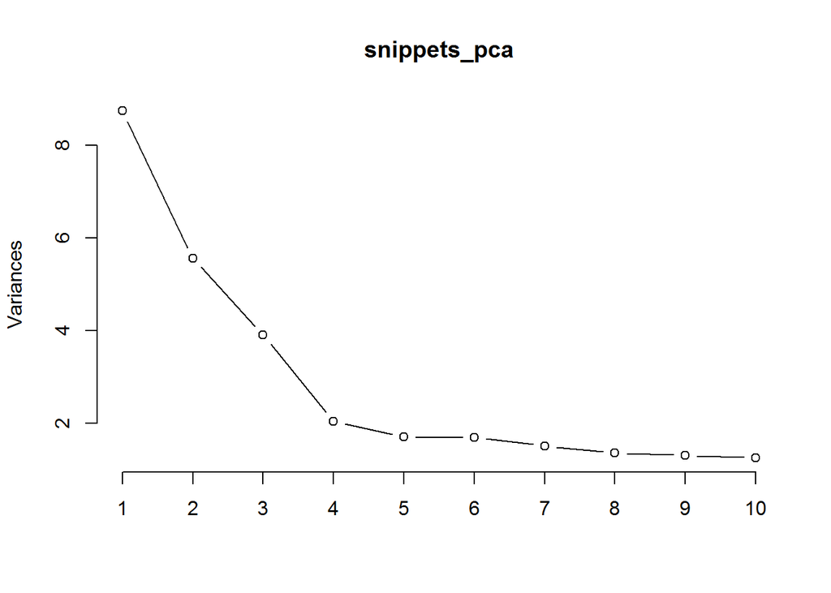

```
# packages for visualization--code taken from
# http://www.r-bloggers.com/computing-and-visualizing-pca-in-r/
g <- ggbiplot(snippets_pca, obs.scale = 1, var.scale = 1,
              groups = authors[authors != "mystery"])
g <- g + theme(legend.direction = 'horizontal',
              legend.position = 'top')
g
```

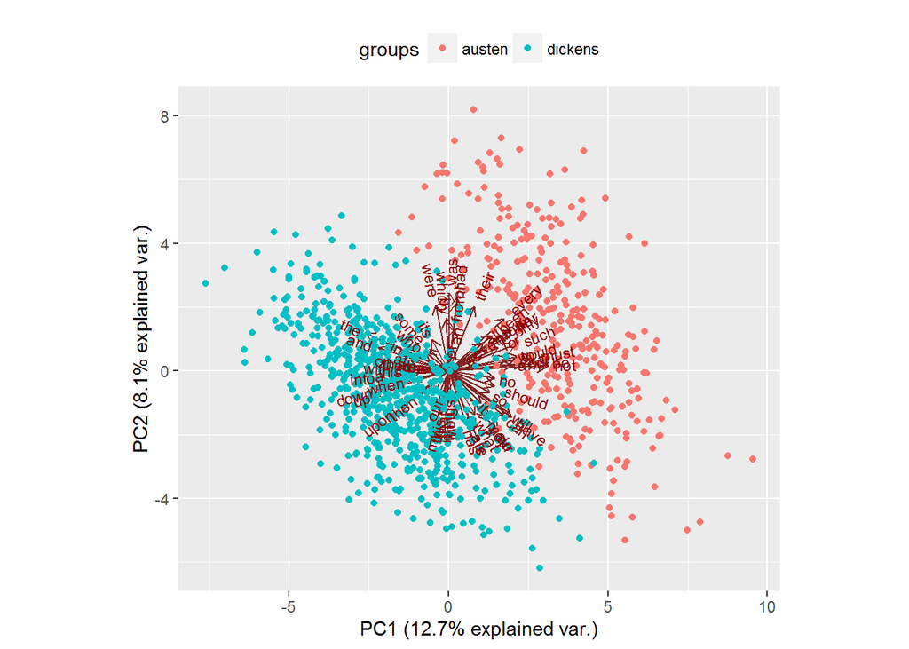

```
## predict: input the dfm (with appropriate features) of the mystery text
dfm.mystery <- dfm(unlist(corpus$blocks[[11]]),
                  keptFeatures = wordlist)
```

```
   ... lowercasing
   ... tokenizing
   ... indexing documents: 13 documents
   ... indexing features: 2,866 feature types
   ... kept 69 features, from 69 supplied (glob) feature types
   ... created a 13 x 69 sparse dfm
   ... complete.
Elapsed time: 0.09 seconds.
```

```
predicted <- predict(snippets_pca, newdata = dfm.mystery)
```

Use Fisher’s linear discrimination rule: choose the group that has a closer group mean on the first 2 dimensions.

```
# this is to determine the number of snippets per author,
# to divide up the results of pca
d <- sum(authors == "dickens", na.rm = TRUE)
a <- sum(authors == "austen", na.rm = TRUE)

# find the mean of the first two PCs
austen_pc1_mean <- mean(snippets_pca$x[1:a,1])
austen_pc2_mean <- mean(snippets_pca$x[1:a,2])
austen_mean <- c(austen_pc1_mean, austen_pc2_mean)

dickens_pc1_mean <- mean(snippets_pca$x[a+1:d,1])
dickens_pc2_mean <- mean(snippets_pca$x[a+1:d,2])
dickens_mean <- c(dickens_pc1_mean, dickens_pc2_mean)

mystery_pc1_mean <- mean(predicted[,1])
mystery_pc2_mean <- mean(predicted[,2])
mystery_mean <- c(mystery_pc1_mean, mystery_pc2_mean)

## now you need to find which is closer to the mystery mean
austen_mean; dickens_mean; mystery_mean
```

```
[1] 3.376243 1.443358
```

```
[1] -1.5845704 -0.6774108
```

```
[1]  4.589222 -1.862394
```

Not entirely clear, but it looks like Austen would be the better bet, since PC1 (the strongest factor) clearly speaks for Austen. Let’s try and use a little trick for visualization purposes (note that the estimates will be slightly biased, but its still useful to get an idea):

```
dfm.blocks.all <- dfm(unlist(corpus$blocks),
                      keptFeatures = wordlist)
```

```
   ... lowercasing
   ... tokenizing
   ... indexing documents: 1,043 documents
   ... indexing features: 31,053 feature types
   ... kept 69 features, from 69 supplied (glob) feature types
   ... created a 1043 x 69 sparse dfm
   ... complete.
Elapsed time: 5.79 seconds.
```

```
pca.all <- prcomp(dfm.blocks.all, center=TRUE, scale.=TRUE)

g <- ggbiplot(pca.all, obs.scale = 1, var.scale = 1,
              groups = authors)
g <- g + theme(legend.direction = 'horizontal',
               legend.position = 'top')
g
```

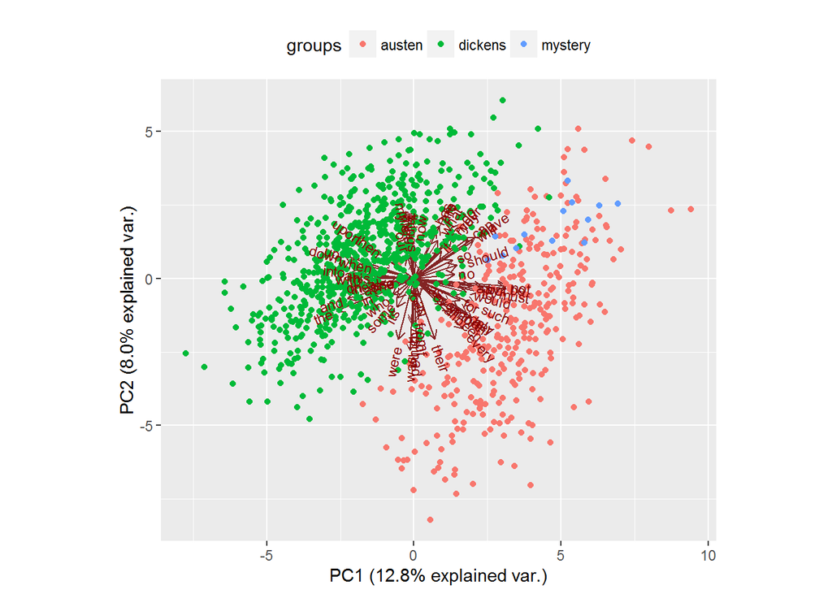

We get the same picture as when calculating the means. However, I think it is fairly clear that we would predict *Austen* for all mystery snippets (since PC1 does a better job at separating the authors and the blue docs are clearly on the Austen side of PC1.

Maybe our analsysis is suffering from outliers? Let’s do a PCA per author and check for that!

```
# Austen
dfm.blocks.austen <- dfm(unlist(corpus$blocks)[authors == "austen"],
                      keptFeatures = wordlist)
```

```
   ... lowercasing
   ... tokenizing
   ... indexing documents: 329 documents
   ... indexing features: 13,506 feature types
   ... kept 69 features, from 69 supplied (glob) feature types
   ... created a 329 x 69 sparse dfm
   ... complete.
Elapsed time: 1.69 seconds.
```

```
pca.austen <- prcomp(dfm.blocks.austen, center=TRUE, scale.=TRUE)
g <- ggbiplot(pca.austen, obs.scale = 1, var.scale = 1,
              groups = titles[authors == "austen"])
g <- g + theme(legend.direction = 'horizontal',
               legend.position = 'top')
g
```

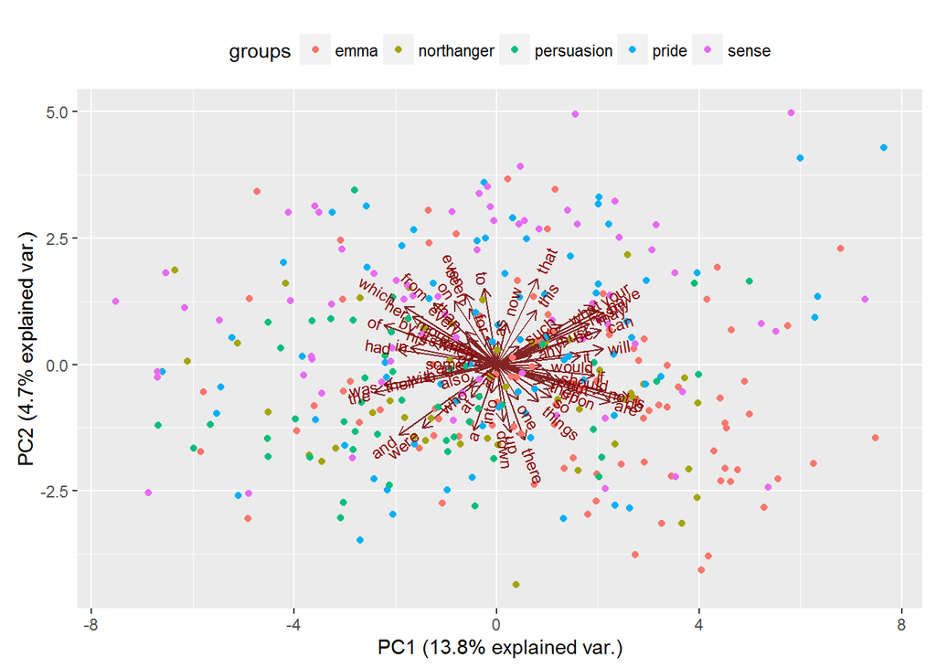

```
# Dickens
dfm.blocks.dickens <- dfm(unlist(corpus$blocks)[authors == "dickens"],
                         keptFeatures = wordlist)
```

```
   ... lowercasing
   ... tokenizing
   ... indexing documents: 701 documents
   ... indexing features: 27,884 feature types
   ... kept 69 features, from 69 supplied (glob) feature types
   ... created a 701 x 69 sparse dfm
   ... complete.
Elapsed time: 4.14 seconds.
```

```
pca.dickens <- prcomp(dfm.blocks.dickens, center=TRUE, scale.=TRUE)
g <- ggbiplot(pca.dickens, obs.scale = 1, var.scale = 1,
              groups = titles[authors == "dickens"])
g <- g + theme(legend.direction = 'horizontal',
               legend.position = 'top')
g
```

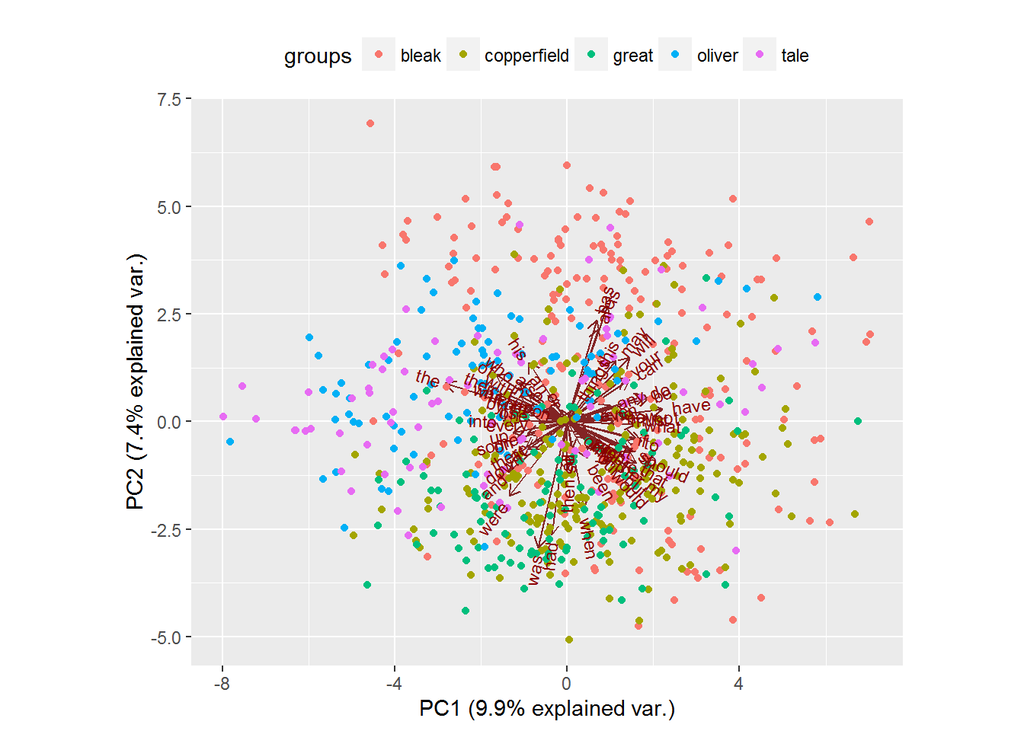

Dickens’ *Bleak* looks a little problematic (scores very high on PC2) -> we might think about excluding some of these points…

## Question 4

Make one huge dfm (corpus$text is lowercase already)

```
all.txt <- paste(corpus$text, collapse = " ")
dfm.all <- dfm(all.txt, removePunct = TRUE)
```

```
   ... lowercasing
   ... tokenizing
   ... indexing documents: 1 document
   ... indexing features: 31,085 feature types
   ... created a 1 x 31085 sparse dfm
   ... complete.
Elapsed time: 6.15 seconds.
```

Demonstrate Zipf’s law (looks a little off to me!):

```
plot(log10(1:100), log10(topfeatures(dfm.all, 100)),
     xlab="log10(rank)", ylab="log10(frequency)", main="Top 100 Words")
# regression to check if slope is approx -1.0
regression <- lm(log10(topfeatures(dfm.all, 100)) ~ log10(1:100))
abline(regression, col="red")
```

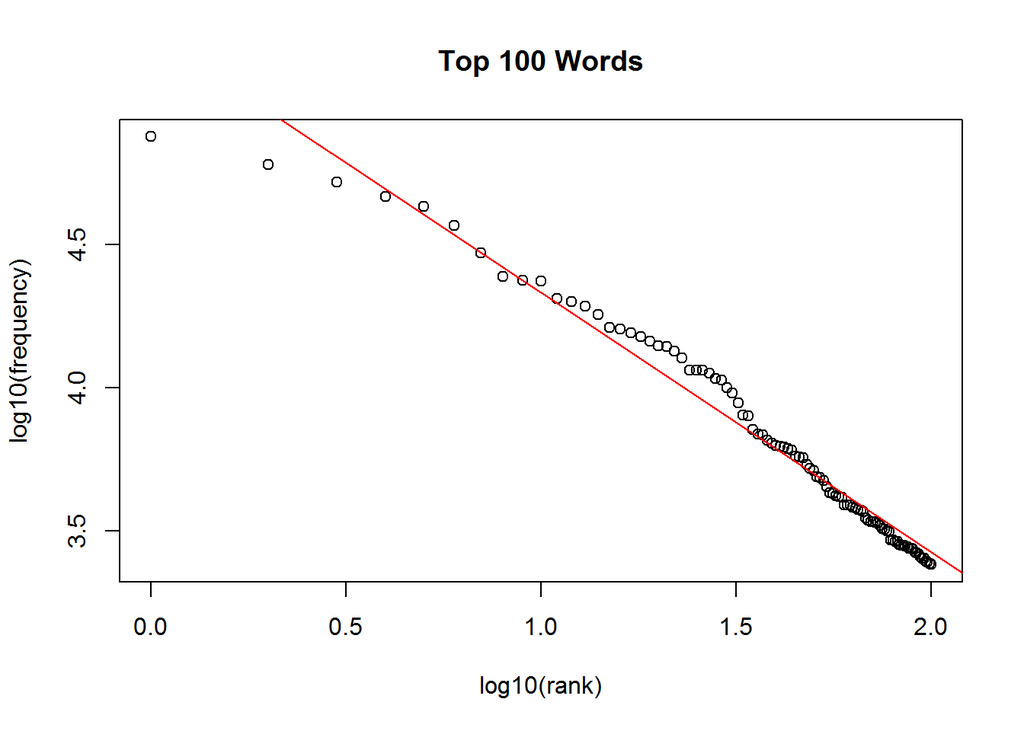

```
confint(regression)
```

```
                  2.5 %     97.5 %
(Intercept)   5.1871734  5.2898915
log10(1:100) -0.9378393 -0.8748147
```

Demonstrate Heap’s law and find optimal $b$.

```
##      M = kT^b
# M = vocab size
# T = number of tokens
# k, b are constants

ntok <- lengths(tokenize(all.txt, removePunct = TRUE))
ntyp <- ntype(dfm.all) # 31085

# prediciton by Heap's law w/ parms from lecture
k <- 44; b <- .49
k * (ntok)^b  # 50819.75 (a lot higher)
```

```
[1] 50819.75
```

```
# optimize for variable b and fixed k = 44
(log(ntyp) - log(k))/log(ntok) # .4558
```

```
    text1
0.4558438
```

## Question 5

Make a corpus for each document and use `kwic`.

```
str(corpus$text[10])
```

```
 chr "produced by judith boss\n\n\n\n\n\n\n\n\na tale of two cities\n\na story of the french revolution\n\nby charles dickens\n\n\nco"| __truncated__
```

```
tale <- corpus$text[corpus$title=="tale"]
pride <- corpus$text[corpus$title=="pride"]

kwic(tale, "class", window = 5)
```

```
                                      contextPre keyword                       contextPost
 [text1, 37171]         all free livers of his [   class ] , from the portrait of
 [text1, 56359]         not yet of the teacher [   class ] , and no ruined nobility
[text1, 100693] nevertheless, monseigneur as a [   class ] had, somehow or other
[text1, 103816]            . monseigneur, as a [   class ] , had dissociated himself from
[text1, 162097]      an inveterate hatred of a [   class ] , opportunity had developed her
```

```
kwic(pride, "class", window = 5)
```

```
                                    contextPre keyword                 contextPost
[text1, 31011] an understanding of the first [   class ] ." elizabeth allowed that
[text1, 76126]  which she would endeavour to [   class ] what mr. darcy had
```

```
kwic(tale, "honoured", window = 5)
```

```
                                 contextPre  keyword                       contextPost
  [text1, 5005]    , and more drafts were [ honoured ] in five minutes than even
 [text1, 19878]       have to kneel to my [ honoured ] father, and implore his
 [text1, 27984] brothers and sisters, and [ honoured ] him more than his(
 [text1, 58351]  could not now touch this [ honoured ] hand." he laid
 [text1, 70248]     one another, held his [ honoured ] parent in view. the
 [text1, 70254]       parent in view. the [ honoured ] parent steering northward, had
 [text1, 70465]       was the form of his [ honoured ] parent, pretty well defined
 [text1, 70650]   at first. presently the [ honoured ] parent appeared to be adjusting
 [text1, 70819]           it, and saw his [ honoured ] parent about to wrench it
[text1, 168748]    that each was not more [ honoured ] and held sacred in the
[text1, 168842]   most of just judges and [ honoured ] men, bringing a boy
```

```
kwic(pride, "honoured", window = 5)
```

```
                                    contextPre  keyword                   contextPost
 [text1, 22452] between yourself and my late [ honoured ] father always gave me much
 [text1, 29297]     expose _him_." elizabeth [ honoured ] him for such feelings,
 [text1, 32286]           i shall hope to be [ honoured ] with the hands of all
 [text1, 39815]      after the death of your [ honoured ] father( who, however
 [text1, 42923] happiness had my fair cousin [ honoured ] me with her hand;
 [text1, 58482]          not but you will be [ honoured ] with some portion of her
 [text1, 62449]       now and then they were [ honoured ] with a call from her
 [text1, 63544]      arrival, that they were [ honoured ] by such an attention,
[text1, 108306]       and his intrigues, all [ honoured ] with the title of seduction
```

```
kwic(tale, "love", window = 5)
```

```
                                     contextPre keyword                       contextPost
  [text1, 4224]         neighbour is dead, my [    love ] , the darling of my
 [text1, 10405]          restore him to life, [    love ] , duty, rest,
 [text1, 18332]        warm young breast, and [    love ] it back to life and
 [text1, 19904]        all night, because the [    love ] of my poor mother hid
 [text1, 22179]            to you by your old [    love ] , or by your little
 [text1, 27877]       known as patriotism, or [    love ] of country. that,
 [text1, 34938]                    it."" lord [    love ] you, no!-
 [text1, 41036]            who will, for pure [    love ] and admiration, bind themselves
 [text1, 42148]       down together, till her [    love ] and company have brought him
 [text1, 50525]        " monseigneur. for the [    love ] of the great god!
 [text1, 56619]              - the way of the [    love ] of a woman. he
 [text1, 57329]         true homage, and deep [    love ] , doctor manette!"
 [text1, 57463]        dear doctor manette, i [    love ] your daughter fondly, dearly
 [text1, 57478]          . if ever there were [    love ] in the world, i
 [text1, 57484]               in the world, i [    love ] her. you have loved
 [text1, 57495]        yourself; let your old [    love ] speak for me!"
 [text1, 57870]          towards you, all the [    love ] and reliance of infancy itself
 [text1, 58147]            , that to bring my [    love ] -- even mine-
 [text1, 58173]              as itself. but i [    love ] her. heaven is my
 [text1, 58182]          is my witness that i [    love ] her!"" i
 [text1, 58786]       place in it against her [    love ] for her father."
 [text1, 58883]  mysteries arise out of close [    love ] , as well as out
 [text1, 59606]      prosper, if lucie should [    love ] you, you shall tell
 [text1, 65791]   you could have returned the [    love ] of the man you see
 [text1, 67182]            to keep a life you [    love ] beside you!" he
 [text1, 82467]        am deeply happy in the [    love ] that heaven has so blessed
 [text1, 82476]               so blessed-- my [    love ] for charles, and charles's
 [text1, 82482]    for charles, and charles's [    love ] for me. but,
 [text1, 82764]                "" believe it, [    love ] ! indeed it is so
 [text1, 83932]               good, but in my [    love ] that was i."
 [text1, 84507]            true to him as her [    love ] aspired to be, and
 [text1, 92261]           i not promise to my [    love ] ?" what, indeed
 [text1, 92561]             and, o my dearest [    love ] !" she urged,
 [text1, 92876]                 - hopes, of a [    love ] as yet unknown to her
 [text1, 94203]   duties seemed to divide her [    love ] for him or her help
[text1, 107192]               paris!" for the [    love ] of heaven, of justice
[text1, 107434]             well, that in his [    love ] for lucie, his renunciation
[text1, 108594]                 - street." my [    love ] to lucie, and to
[text1, 108976]             journey." for the [    love ] of heaven, of justice
[text1, 112877]               added," for the [    love ] of liberty;" which
[text1, 115771]           be so terrified, my [    love ] . i solemnly swear to
[text1, 117062]           kind of armoury, my [    love ] ." twice more in
[text1, 124276]               me your arm, my [    love ] . pass from here with
[text1, 129372]                  stairs."" my [    love ] , the staircase is as
[text1, 131056]    nothing has ever turned my [    love ] away from!" cried
[text1, 138336]    have secured to myself the [    love ] and attachment, the gratitude
[text1, 140660]         , so full of admiring [    love ] and pitying tenderness, yet
[text1, 149144]       nothing in her face but [    love ] and consolation." if
[text1, 149286]     my parting blessing on my [    love ] . we shall meet again
[text1, 149552]           hearts, and all our [    love ] and duty. heaven be
[text1, 150044]         of all the people who [    love ] her, bear to see
[text1, 150160]                 ," a life you [    love ] ." when he had
[text1, 155728]      of his own last grateful [    love ] and blessing, and her
[text1, 160292] guillotine goes handsomely. i [    love ] it. hi forward.
[text1, 165283] with the vigorous tenacity of [    love ] , always so much stronger
[text1, 167936]           like myself, whom i [    love ] very dearly. she is
```

```
kwic(pride, "love", window = 5)
```

```
                                              contextPre keyword
   [text1, 425]                  that he _may_ fall in [    love
  [text1, 2019]                    anything. lydia, my [    love
  [text1, 2249]        certain step towards falling in [    love
  [text1, 6771]                     to be very much in [    love
  [text1, 6964]                 enough to be really in [    love
  [text1, 7183]            more leisure for falling in [    love
  [text1, 9293]            it jumps from admiration to [    love
  [text1, 9296]               admiration to love, from [    love
 [text1, 10271]                       ; make haste, my [    love
 [text1, 15677]                     in town so much in [    love
 [text1, 15772]              of poetry in driving away [    love
 [text1, 15787]                poetry as the _food_ of [    love
 [text1, 15801]                   fine, stout, healthy [    love
 [text1, 20468]           such acquaintances. i dearly [    love
 [text1, 21991]                         day. lydia, my [    love
 [text1, 40854]             your wish of increasing my [    love
 [text1, 41109] silent contemplation of his successful [    love
 [text1, 44625]                 that her brother is in [    love
 [text1, 44715]                 have seen half as much [    love
 [text1, 44870]                  , instead of being in [    love
 [text1, 44879]                     he is very much in [    love
 [text1, 45749]                   to hope that so much [    love
 [text1, 46362]      longing to publish his prosperous [    love
 [text1, 46880]        . collins's fancying himself in [    love
 [text1, 48803]                others, the business of [    love
 [text1, 50078]               few people whom i really [    love
 [text1, 50869]                    ; no wonder if they [    love
 [text1, 51195]              your sister is crossed in [    love
 [text1, 51218]                 be crossed a little in [    love
 [text1, 51534]           week spent in professions of [    love
 [text1, 52188]                   , so easily falls in [    love
 [text1, 52277]               whom he was violently in [    love
 [text1, 52294]            expression of' violently in [    love
 [text1, 52346]            _violent was_ mr. bingley's [    love
 [text1, 52431]         incivility the very essence of [    love
 [text1, 52445]                      - of that kind of [    love
 [text1, 53039]                to be very seriously in [    love
 [text1, 53357]                      lizzy, to fall in [    love
 [text1, 53559]                     he shall not be in [    love
```

[output cut: 131 more lines]

```
[text1, 128062] ] , i want to speak
[text1, 136394] ] can be supposed to do
[text1, 138961] ] him so well as i
[text1, 139153] ] him quite well enough?
[text1, 139225] ] him better than i do
[text1, 139395] ] of you, i must
[text1, 140443] ] him. indeed he has
[text1, 140904] ] for you, and there
[text1, 141439] ] , tell me what dish
[text1, 141666] ] with her." how
[text1, 141995] ] ."" was there
[text1, 142475] ] me. my avowed one
[text1, 142897] ] in the world that he
[text1, 144106] ] mr. darcy half as
[text1, 144599] ] each other even as well
```

```
kwic(tale, "revolution", window = 5)
```

```
                                      contextPre    keyword                        contextPost
    [text1, 15]          a story of the french [ revolution ] by charles dickens contents book
   [text1, 897]         be his tumbrils of the [ revolution ] . but that woodman and
[text1, 105505]       to talk of this terrible [ revolution ] as if it were the
[text1, 108178] influence to guide this raging [ revolution ] that was running so fearfully
[text1, 121762]  wicked and distracted had the [ revolution ] grown in that december month
[text1, 123647]     they danced to the popular [ revolution ] song, keeping a ferocious
[text1, 140750]        could have been no such [ revolution ] , if all laws,
[text1, 140775]  the suicidal vengeance of the [ revolution ] was to scatter them all
[text1, 159277]            his right mind? the [ revolution ] - fever will have been
```

```
kwic(pride, "revolution", window = 5)
```

```
                                      contextPre    keyword                contextPost
[text1, 143994] , their characters suffered no [ revolution ] from the marriage of her
```

```
# yes!
kwic(tale, "justice", window = 5)
```

```
                                  contextPre keyword               contextPost
 [text1, 25212]      dock at my lord chief [ justice ] himself, and pulled him
 [text1, 36625]   visage of the lord chief [ justice ] in the court of king's
 [text1, 46613] chambers, the tribunals of [ justice ] , and all society(
 [text1, 57357]               it. i do you [ justice ] ; i believe it.
[text1, 107197]         love of heaven, of [ justice ] , of generosity, of
[text1, 108045]           of death, to his [ justice ] , honour, and good
[text1, 108981]         love of heaven, of [ justice ] , of generosity, of
[text1, 161713]     of mind to impeach the [ justice ] of the republic. she
```

```
kwic(pride, "justice", window = 5)
```

```
                                        contextPre keyword                  contextPost
 [text1, 16781]              not room to do them [ justice ] ."" oh!
 [text1, 17382]             . bingley did not do [ justice ] to his own disposition.
 [text1, 18797]        for what painter could do [ justice ] to those beautiful eyes?
 [text1, 29001]                  me. i cannot do [ justice ] to his kindness. he
 [text1, 49968]             i had never done you [ justice ] , or loved you as
 [text1, 72366]              i demand it of your [ justice ] ." two offenses of
 [text1, 75419]            any wish of doing him [ justice ] . he expressed no regret
 [text1, 77118]       neither could she deny the [ justice ] of his description of jane
 [text1, 77190]            shame was severe. the [ justice ] of the charge struck her
 [text1, 82877]           will do him such ample [ justice ] , that i am growing
 [text1, 84591]              . she felt anew the [ justice ] of mr. darcy's objections
 [text1, 97732]               , however, did her [ justice ] , and pitied her.
[text1, 103825]               i am not doing her [ justice ] . but she is very
[text1, 136930] reasonable enough to allow their [ justice ] ."" i was
[text1, 142874]            but not one with such [ justice ] . i am happier even
```

## Question 6

Read in the `ukManifestosCorpus`, split into sentences, make `overview` matrix and `years` vector to keep track of which sentence belongs to which document.

```
data("ukManifestosCorpus")
names(ukManifestosCorpus$documents)
```

```
[1] "texts"    "Country"  "Type"     "Year"     "Language" "Party"    "_source"
```

```
cons <- subset(ukManifestosCorpus$documents, Party == "Con")
str(cons) # a data.frame
```

```
'data.frame':   16 obs. of  7 variables:
 $ texts   : chr  "CONSERVATIVE PARTY: 1945 \nMr. Churchill's Declaration of Policy to the Electors\n\nI had hoped to preserve the Coalition Gover"| __truncated__ "CONSERVATIVE PARTY: 1950 \nThis is the Road:\nThe Conservative and Unionist Party's Policy\n\nAs Leader of the Conservative and"| __trun…
 $ Country : chr  "UK" "UK" "UK" "UK" ...
 $ Type    : chr  "natl" "natl" "natl" "natl" ...
 $ Year    : chr  "1945" "1950" "1951" "1955" ...
 $ Language: chr  "en" "en" "en" "en" ...
 $ Party   : chr  "Con" "Con" "Con" "Con" ...
 $ _source : chr  "/Users/kbenoit/Dropbox/QUANTESS/corpora/ukManRenamed/UK_natl_1945_en_Con.txt" "/Users/kbenoit/Dropbox/QUANTESS/corpora/ukManRenamed/UK_natl_1950_en_Con.txt" "/Users/kbenoit/Dropbox/QUANTESS/corpora/ukManRenamed/UK_natl_1951_en_Con.txt" "/Users/kbenoit/Dropbox/QUANTESS/corpora/ukMa…
```

```
str(cons$texts)
```

```
 chr [1:16] "CONSERVATIVE PARTY: 1945 \nMr. Churchill's Declaration of Policy to the Electors\n\nI had hoped to preserve the Coalition Gover"| __truncated__ ...
```

```
cons$sentences <- tokenize(cons$text, "sentence")
class(cons$sentences)
```

```
[1] "tokenizedTexts" "list"
```

```
str(cons$sentences)
```

```
List of 16
 $ : chr [1:292] "CONSERVATIVE PARTY: 1945" "Mr. Churchill's Declaration of Policy to the Electors" "I had hoped to preserve the Coalition Government, comprising all Parties in the State, until the end of the Japanese war, but o"| __truncated__ "It is a strong Government, containing many of those wh…
 $ : chr [1:430] "CONSERVATIVE PARTY: 1950" "This is the Road:" "The Conservative and Unionist Party's Policy" "As Leader of the Conservative and Unionist Party I submit this manifesto of our beliefs and policy to the British electors." ...
 $ : chr [1:144] "CONSERVATIVE PARTY: 1951" "We are confronted with a critical Election which may well be the turning point in the fortunes and even the life of Britain." "We cannot go on with this evenly balanced Party strife and hold our own in the world, or even earn our living." "The prime need …
 $ : chr [1:657] "CONSERVATIVE PARTY: 1955" "United for Peace and Progress:" "The Conservative and Unionist Party's Policy" "A PERSONAL STATEMENT BY THE PRIME MINISTER" ...
 $ : chr [1:286] "LABOUR MANIFESTO 1959" "Britain Belongs to You:" "The Labour Party's Policy for Consideration by the British People" "We welcome this Election; it gives us, at last, the chance to end eight years of Tory rule." ...
 $ : chr [1:470] "CONSERVATIVE" "\"PROSPERITY WITH A PURPOSE\"" "Foreward" "by Sir Alec Douglas-Home" ...
 $ : chr [1:307] "CONSERVATIVE PARTY: 1966" "Action Not Words:" "The New Conservative Programme" "FOREWORD" ...
 $ : chr [1:585] "CONSERVATIVE PARTY: 1970" "A Better Tomorrow" "FOREWORD" "This Manifesto sets out the policies of the Conservative Party for a better Britain." ...
 $ : chr [1:807] "Conservative Manifesto: October 1974" "Putting Britain First" "A national policy" "The dangers now facing Britain are greater than any we have seen since the last war." ...
 $ : chr [1:10953] "Conservative Party Manifesto 1979" "Conservative manifesto, 1979" "Contents" "FOREWORD by The Rt." ...
 $ : chr [1:699] "CONSERVATIVE PARTY: 1983" "FOREWORD - THE CHALLENGE OF OUR TIMES" "In the last four years, Britain has recovered her confidence and self-respect." "We have regained the regard and admiration of other nations." ...
 $ : chr [1:1095] "CONSERVATIVE PARTY: 1987" "The Next Moves Forward" "FOREWORD" "In the last eight years our country has changed - changed for the better." ...
 $ : chr [1:1811] "Conservative Party 1992" "The Best Future for Britain" "FOREWORD" "At the end of this Parliament a new Millennium will be in view We must raise our sights high." ...
 $ : chr [1:2628] "THE CONSERVATIVE MANIFESTO 1997" "FOREWORD" "THE CONSERVATIVE ADMINISTRATIONS ELECTED SINCE 1979 ARE AMONG THE MOST" "SUCCESSFUL IN BRITISH PEACETIME HISTORY." ...
 $ : chr [1:931] "time for common sense - the Conservative manifesto" "introduction" "through our lives:" "* raising a family" ...
 $ : chr [1:487] "ARE YOU THINKING WHAT WE'RE THINKING?" "IT'S TIME FOR ACTION" "CONSERVATIVE ELECTION MANIFESTO 2005" "THE BRITISH DREAM" ...
 - attr(*, "class")= chr [1:2] "tokenizedTexts" "list"
 - attr(*, "what")= chr "sentence"
 - attr(*, "ngrams")= int 1
 - attr(*, "concatenator")= chr ""
```

```
str(cons$sentences[1])
```

```
List of 1
 $ : chr [1:292] "CONSERVATIVE PARTY: 1945" "Mr. Churchill's Declaration of Policy to the Electors" "I had hoped to preserve the Coalition Government, comprising all Parties in the State, until the end of the Japanese war, but o"| __truncated__ "It is a strong Government, containing many of those wh…
```

```
# but which sentence belongs to which doc?
overview <- data.frame(party = character(), year = numeric(),
                       nsentences = numeric(), stringsAsFactors=FALSE)
for (i in 1:length(cons$sentences)) {
  overview[i,1] <- cons$Party[i]
  overview[i,2] <- cons$Year[i]
  overview[i,3] <- length(cons$sentences[[i]])
}
overview
```

```
   party year nsentences
1    Con 1945        292
2    Con 1950        430
3    Con 1951        144
4    Con 1955        657
5    Con 1959        286
6    Con 1964        470
7    Con 1966        307
8    Con 1970        585
9    Con 1974        807
10   Con 1979      10953
11   Con 1983        699
12   Con 1987       1095
13   Con 1992       1811
14   Con 1997       2628
15   Con 2001        931
16   Con 2005        487
```

```
years <- vector("numeric")
for (i in 1:length(cons$sentences)) {
  years <- c(years, rep(overview$year[i], overview$nsentences[i]))
}
# check
length(cons$sentences) == length(unique(years))
```

```
[1] TRUE
```

```
length(unlist(cons$sentences)) == length(years)
```

```
[1] TRUE
```

Create a df and clean using Kevin’s functions:

```
df <- data.frame(years, as.character(unlist(cons$sentences)),
                 stringsAsFactors = FALSE)
names(df) <- c("years", "sentences")
apply(df, 2, FUN = function(x) class(x))
```

```
      years   sentences
"character" "character"
```

```
# apply Kevin's functions
df2 <- filter(df, grepl("^\\?", df$sentences)==FALSE &grepl("^\\d", df$sentences) ==FALSE)
df2 <- filter(df, ntoken(df$sentences)>3)

# check results
nrow(df2); nrow(df)
```

```
[1] 19759
```

```
[1] 22582
```

```
head(df$sentences[!(df$sentences %in% df2$sentences)], 10)
```

```
 [1] "DEFENCE"               "WORK"                  "HOMES"                 "FOOD AND AGRICULTURE"
 [5] "NATIONAL INSURANCE"    "HEALTH"                "EDUCATION"             "OVERSEAS TRADE"
 [9] "INDUSTRIAL EFFICIENCY" "MONOPOLIES"
```

```
head(df2$sentences, 10)
```

```
 [1] "CONSERVATIVE PARTY: 1945"
 [2] "Mr. Churchill's Declaration of Policy to the Electors"
 [3] "I had hoped to preserve the Coalition Government, comprising all Parties in the State, until the end of the Japanese war, but owing to the unwillingness of the Socialist and Sinclair Liberal Parties to agree to my proposal, a General Election became inevitable, and I have formed a new National…
 [4] "It is a strong Government, containing many of those who helped me to carry the burdens of State through the darkest days and on whose counsel and executive ability I have learned to rely."
 [5] "We seek the good of the whole nation, not that of one section or one faction."
 [6] "We believe in the living unity of the British people, which transcends class or party differences."
 [7] "It was this living unity which enabled us to stand like a rock against Germany when she over-ran Europe."
 [8] "Upon our power to retain unity, the future of this country and of the whole world largely depends."
 [9] "Britain is still at war, and must not turn aside from the vast further efforts still needed to bring Japan to the same end as Germany."
[10] "Even when all foreign enemies are utterly defeated, that will not be the end of our task."
```

```
# overwrite
df <- df2
```

Readability:

```
# mean for all sentences
mean(readability(df$sentences, "Dale.Chall"))
```

```
[1] 20.47022
```

```
# mean by year
readability(texts(df$sentences, groups = as.factor(df$years)),
            c("Flesch", "Dale.Chall"))
```

[output not shown]

```
# correlations are low because we are evaluating single sentences here!
cor(readability(df$sentences, c("Flesch", "Dale.Chall")))
```

```
           Dale.Chall    Flesch
Dale.Chall  1.0000000 0.6252198
Flesch      0.6252198 1.0000000
```

Bootstrapping using `boot`:

```
library(boot)
bsReadabilityByGroup <- function(x, i, groups = NULL, measure = "Flesch") {
  readability(texts(x[i], groups = groups), measure)
}

R <- 300
groups <- as.factor(df$years)
b <- boot(texts(df$sentences), bsReadabilityByGroup, strata = groups, R = R, groups = groups)
# t0 is observed value
# t is the matrix with dim(R,groups) containing the BS replicates
colnames(b$t) <- names(b$t0)
apply(b$t, 2, quantile, c(.025, .5, .975))
```

```
          1945     1950     1951     1955     1959     1964     1966     1970     1974     1979
2.5%  46.02512 43.40153 48.92786 47.17607 45.91653 41.81276 45.16873 42.94039 42.02340 20.58172
50%   48.34550 45.84394 52.54933 48.79267 48.13200 43.96040 47.97304 44.92815 43.41433 22.44369
97.5% 50.77960 48.14692 56.41407 50.42913 50.77360 45.94173 50.55273 46.96856 45.00517 24.05071
          1983     1987     1992     1997     2001     2005
2.5%  44.68537 43.16828 46.20891 46.60762 46.45925 48.02417
50%   46.52808 44.79165 47.23056 47.99203 47.94433 50.19835
97.5% 48.32216 46.46496 48.31126 49.46916 49.65485 52.74111
```

```
# here are our SE's :)
```

Bootstrapping using our custom function:

```
# initialize
year_FRE <- data.frame(matrix(nrow = 100, ncol = length(unique(df$years))))

for(i in 1:100){
  #sample 3000 (high value to make sure we get all the years!)
  bootstrapped <- sample_n(df, 3000, replace=TRUE)
  bootstrapped$read_FRE <- readability(bootstrapped$sentences, "Flesch")
  #store results
  year_FRE[i,]<-aggregate(bootstrapped$read_FRE, by=list(bootstrapped$year), FUN=mean)[,2]
}

#name the data frames
colnames(year_FRE)<-names(table(df$year))
```

Define the standard error function, calculate standard errors and point estimates.

```
std <- function(x) sd(x)/sqrt(length(x))

ses <- apply(year_FRE, 2, std)
coefs <- apply(year_FRE, 2, mean)
```

Now, get empirical (non-bootstrapped) means for comparison.

```
table(df$years)
```

```
1945 1950 1951 1955 1959 1964 1966 1970 1974 1979 1983 1987 1992 1997 2001 2005
 277  383  143  617  267  415  303  564  733 9150  664 1047 1686 2216  841  453
```

```
df$read_FRE <- readability(df$sentences, "Flesch")
coefs_obs <- aggregate(df$read_FRE, by=list(df$years), FUN=mean)[,2]
# the following yields wrong results!
# coefs_obs <- readability(texts(df$sentences, groups = as.factor(df$years)), "Flesch")
```

Make plot.

```
nyears <- length(unique(df$years))
y.axis <- c(1:nyears)
min <- min(min(coefs - 2*ses - .2), min(coefs_obs)-.5)
max <- max(max(coefs + 2*ses + .2), max(coefs_obs)+.5)
var.names <- colnames(year_FRE)
adjust <- 0
par(mar=c(2,8,2,2))

plot(coefs, y.axis, type = "p", axes = F, xlab = "", ylab = "", pch = 19, cex = .8,
     xlim=c(min,max),ylim = c(.5, nyears+.5),
     main = "Bootstrapped Yearly FRE Scores for Cons. Party\n[Point Estimates, and 95/97.5% CIs]", cex.main = .6)

# make color vector for rects
pal <- c("grey97", "grey95")
colvec <- rep(pal, length.out = nyears)
# make rects
minval <- -.5; maxval <- .5
for (i in 1:nyears) {
  rect(min, minval + i, max, maxval + i,
       col = colvec[i], border="grey90", lty = 2)
}
axis(1, at = seq(min,max,(max-min)/10),
     labels = c(round(min+0*((max-min)/10),3),
                round(min+1*((max-min)/10),3),
                round(min+2*((max-min)/10),3),
                round(min+3*((max-min)/10),3),
                round(min+4*((max-min)/10),3),
                round(min+5*((max-min)/10),3),
                round(min+6*((max-min)/10),3),
                round(min+7*((max-min)/10),3),
                round(min+8*((max-min)/10),3),
                round(min+9*((max-min)/10),3),
                round(max,3)),tick = T,cex.axis = .75, mgp = c(2,.7,0))
axis(2, at = y.axis, label = var.names, las = 1, tick = FALSE, cex.axis =.8)
abline(h = y.axis, lty = 2, lwd = .5, col = "white")
segments(coefs-qnorm(.975)*ses, y.axis+2*adjust, coefs+qnorm(.975)*ses, y.axis+2*adjust, lwd =  1)

segments(coefs-qnorm(.95)*ses, y.axis+2*adjust-.035, coefs-qnorm(.95)*ses, y.axis+2*adjust+.035, lwd = .9)
segments(coefs+qnorm(.95)*ses, y.axis+2*adjust-.035, coefs+qnorm(.95)*ses, y.axis+2*adjust+.035, lwd = .9)
points(coefs, y.axis+2*adjust,pch=21,cex=.8, col = "black", bg="white")

# plot empirical points
points(coefs_obs, y.axis+2*adjust,pch=16, col="red", cex = .5)
# note that we have one outlier!

# make legend
legend(43.2, 16, c("empirical means", "bootstrapped means"), pch = c(16,21),
            col = c("red", "black"), bg = c("white", "white"), cex = .5)
```

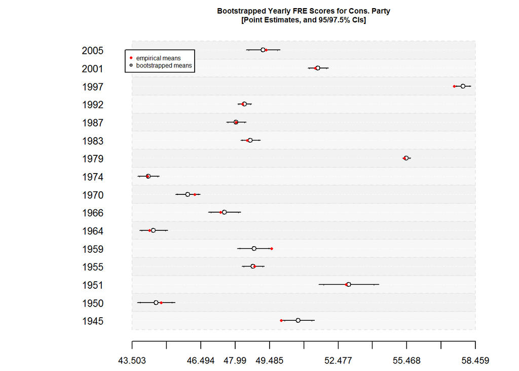

Check some results.

```
## interesting:
fre.1979 <- readability(texts(df$sentences[df$years == 1979]), "Flesch")
fre.1951 <- readability(texts(df$sentences[df$years == 1951]), "Flesch")
# FRE mostly is btw. 0 and 100
# however:
summary(fre.1979)
```

```
   Min. 1st Qu.  Median    Mean 3rd Qu.    Max.
-218.20   37.90   57.23   55.36   75.88  204.80
```

```
summary(fre.1951)
```

```
   Min. 1st Qu.  Median    Mean 3rd Qu.    Max.
 -7.768  33.980  51.520  52.810  69.410 139.300
```

```
df$sentences[df$years == 1979][fre.1979 == min(fre.1979)]
```

```
[1] "locally-elected politicians."
```

```
readability("locally-elected politicians.", "Flesch")
```

```
   text1
-218.195
```

```
df$sentences[df$years == 1979][fre.1979 == max(fre.1979)]
```

```
[1] "  1989/90;"
```

```
readability("  1989/90;", "Flesch")
```

```
  text1
204.805
```

We can see: We still have bad sentence detection -> Should use better SBD tools/maybe do a little more pre-processing.

** END OF DOCUMENT **